# Movie Recommender System

**Mountain View Streaming Platform** — personalised Top-5 recommendations for returning users

## 1. Business Understanding

### Background

Mountain view streaming platform wants to reduce churn by personalising the home screen for returning users who have rated at least 10 movies. Users are more likely to leave the platform when the recommended content does not match their preference.

### Problem Statement

Given a user's historical movie ratings, predict which unseen movies they are most likely to enjoy, and surface the Top-5 as personalised recommendations.

### Business objectives

1.Increase user retention by improving the relevance of movie recommendations shown to returning users

2.Increase User engagement

3.Balance popular content with personalised recommendations

4.Support new and returning Users

### Success Criteria

> SVD outperforms KNNBasic

> Hyperparameter tuning improves SVD

> Generate Top-5 personalized recommendations

> Address cold-start users

| Metric | Target | Why it matters |
| --- | --- | --- |
| RMSE | < 0.90 | Predicted ratings are close to actual; penalises large errors heavily |
| MAE | < 0.70 | Average error is small and easy to interpret |
| Precision@5 | > 0.70 | ≥ 70% of surfaced movies match user preferences |
| Recall@5 | > 0.40 | System discovers ≥ 40% of movies the user would have liked |

## 2. IMPORTS

```python
#Importing libraries
import pandas as pd
import numpy as np
import matplotlib.pyplot as plt
import seaborn as sns
from collections import defaultdict

from surprise import Dataset, Reader, SVD
from surprise.prediction_algorithms.knns import KNNBasic
from surprise import accuracy
from surprise.model_selection import train_test_split, cross_validate, GridSearchCV

from sklearn.preprocessing import normalize

from sklearn.feature_extraction.text import TfidfVectorizer
from sklearn.metrics.pairwise import cosine_similarity

import warnings
warnings.filterwarnings('ignore')

sns.set_style('whitegrid')
plt.rcParams['figure.dpi'] = 100
```

## 3. DATA UNDERSTANDING

```python
# Load data
ratings = pd.read_csv('ratings.csv')
movies  = pd.read_csv('movies.csv')

print('ratings shape:', ratings.shape)
print('movies  shape:', movies.shape)
```

```
ratings shape: (32000204, 4)
movies  shape: (87585, 3)
```

```python
#rating information
ratings.info()
```

```
<class 'pandas.core.frame.DataFrame'>
RangeIndex: 32000204 entries, 0 to 32000203
Data columns (total 4 columns):
 #   Column     Dtype
---  ------     -----
 0   userId     int64
 1   movieId    int64
 2   rating     float64
 3   timestamp  int64
dtypes: float64(1), int64(3)
memory usage: 976.6 MB
```

```python
#movie information
movies.info()
```

```
<class 'pandas.core.frame.DataFrame'>
RangeIndex: 87585 entries, 0 to 87584
Data columns (total 3 columns):
 #   Column   Non-Null Count  Dtype
---  ------   --------------  -----
 0   movieId  87585 non-null  int64
 1   title    87585 non-null  object
 2   genres   87585 non-null  object
dtypes: int64(1), object(2)
memory usage: 2.0+ MB
```

```python
#Count unique users
print('Unique users  :', ratings['userId'].nunique())
#Count unique movies
print('Unique movies :', ratings['movieId'].nunique())
#Check rating range
print('Rating range  :', ratings['rating'].min(), '–', ratings['rating'].max())
#statistics check
ratings['rating'].describe()
```

```
Unique users  : 200948
Unique movies : 84432
Rating range  : 0.5 – 5.0
```

```
count    3.200020e+07
mean     3.540396e+00
std      1.058986e+00
min      5.000000e-01
25%      3.000000e+00
50%      3.500000e+00
75%      4.000000e+00
max      5.000000e+00
Name: rating, dtype: float64
```

## Summary of the data

Rating has 32 million count,

the mean rating is 3.5,

The maximum rating is 5 while the minimum is 0.5.

Rating csv contains floating and intergers.

Movie csv contain intergers and object

## 4.Data Cleaning & Preprocessing

```python
# Missing values
print('ratings nulls:\n', ratings.isnull().sum())
print()
print('movies nulls:\n', movies.isnull().sum())
```

```
ratings nulls:
 userId       0
movieId      0
rating       0
timestamp    0
dtype: int64

movies nulls:
 movieId    0
title      0
genres     0
dtype: int64
```

```python
# Duplicates
print('ratings duplicates:', ratings.duplicated().sum())
print('movies duplicates :', movies.duplicated().sum())

ratings = ratings.drop_duplicates()
movies  = movies.drop_duplicates()
```

```
ratings duplicates: 0
movies duplicates : 0
```

```python
# Reduce to 100K sample
ratings = ratings.sample(n=100_000, random_state=42).reset_index(drop=True)
print('Working dataset size:', ratings.shape)

# Merge titles
movie_ratings = ratings.merge(movies, on='movieId')
print('Merged shape:', movie_ratings.shape)
movie_ratings.head()
```

```
Working dataset size: (100000, 4)
Merged shape: (100000, 6)
```

|  | userId | movieId | rating | timestamp | title | genres |
| --- | --- | --- | --- | --- | --- | --- |
| 0 | 66954 | 781 | 5.0 | 850944577 | Stealing Beauty (1996) | Drama |
| 1 | 87551 | 781 | 5.0 | 851419074 | Stealing Beauty (1996) | Drama |
| 2 | 85551 | 781 | 4.0 | 956585282 | Stealing Beauty (1996) | Drama |
| 3 | 155302 | 781 | 3.0 | 1435700489 | Stealing Beauty (1996) | Drama |
| 4 | 19919 | 781 | 3.0 | 1047555105 | Stealing Beauty (1996) | Drama |

## 5 .Exploratory Data Analysis

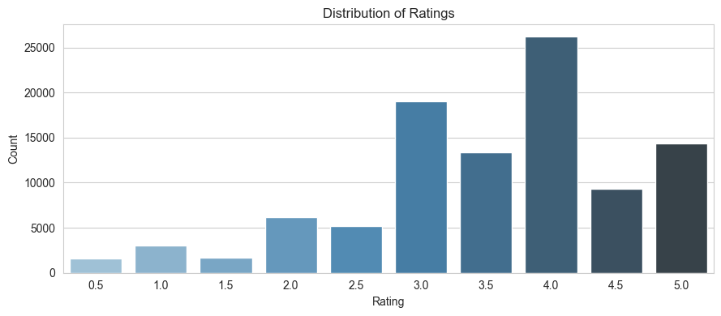

```
Most ratings cluster between 3.0–4.5, indicating a positive bias.
RMSE will naturally reflect this skew.
```

```python
#Distribution of ratings
plt.figure(figsize=(9, 4))
sns.countplot(x='rating', data=ratings, palette='Blues_d')
plt.title('Distribution of Ratings')
plt.xlabel('Rating')
plt.ylabel('Count')
plt.tight_layout()
plt.show()
print('Most ratings cluster between 3.0–4.5, indicating a positive bias.\n'
      'RMSE will naturally reflect this skew.')
```

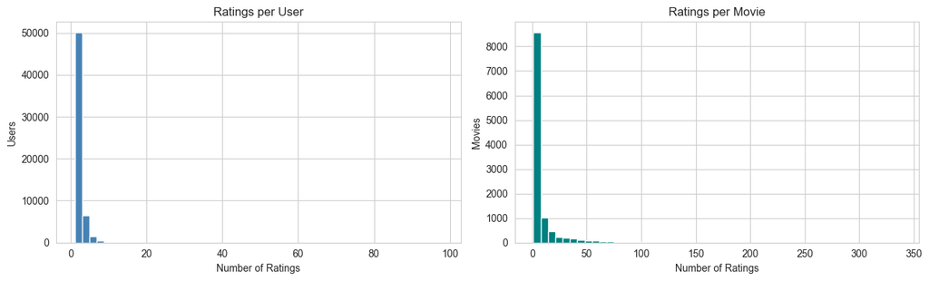

```
Both distributions are heavily right-skewed — a small number of
power users and blockbuster movies dominate. This is the long-tail problem.
```

```python
# Ratings per user
user_counts = ratings.groupby('userId')['rating'].count()

fig, axes = plt.subplots(1, 2, figsize=(13, 4))
user_counts.hist(bins=50, ax=axes[0], color='steelblue', edgecolor='white')
axes[0].set_title('Ratings per User')
axes[0].set_xlabel('Number of Ratings')
axes[0].set_ylabel('Users')

movie_counts = ratings.groupby('movieId')['rating'].count()
movie_counts.hist(bins=50, ax=axes[1], color='teal', edgecolor='white')
axes[1].set_title('Ratings per Movie')
axes[1].set_xlabel('Number of Ratings')
axes[1].set_ylabel('Movies')

plt.tight_layout()
plt.show()
print('Both distributions are heavily right-skewed — a small number of\n'
      'power users and blockbuster movies dominate. This is the long-tail problem.')
```

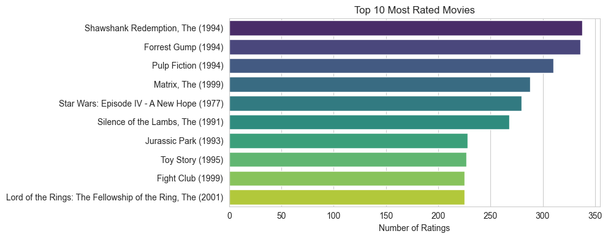

```python
 #Top 10 most rated movies
top_movies = (
    ratings.groupby('movieId')['rating']
    .count()
    .sort_values(ascending=False)
    .head(10)
    .reset_index()
    .merge(movies, on='movieId')
    .rename(columns={'rating': 'num_ratings'})
)

plt.figure(figsize=(10, 4))
sns.barplot(data=top_movies, y='title', x='num_ratings', palette='viridis')
plt.title('Top 10 Most Rated Movies')
plt.xlabel('Number of Ratings')
plt.ylabel('')
plt.tight_layout()
plt.show()
```